# PRESENTACIÓN

### PAZ Y EXPORTACIÓN

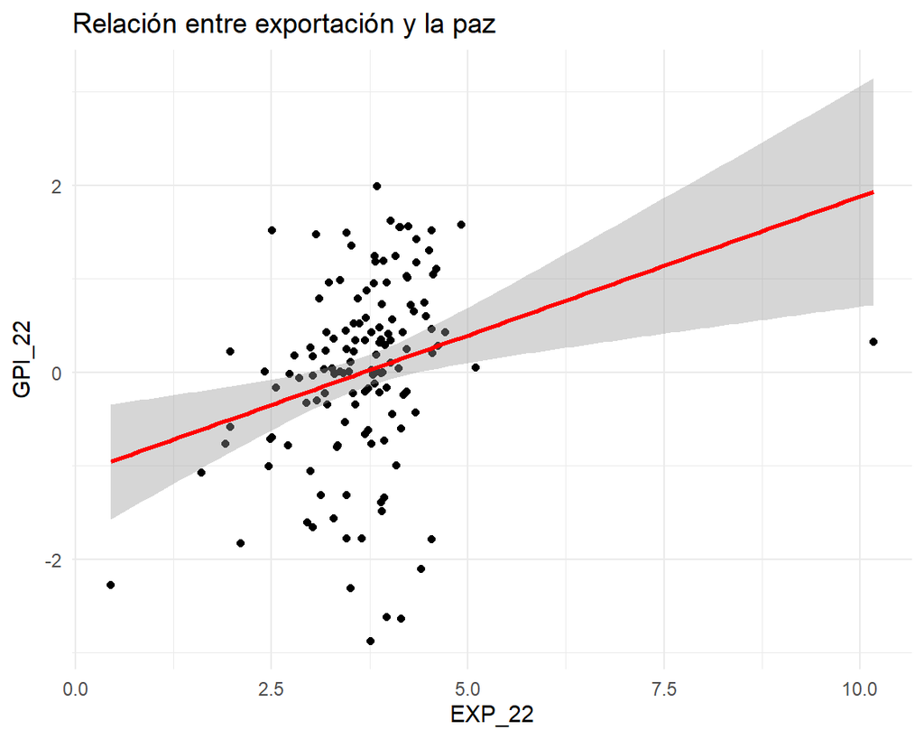

```
     (Intercept) GPI_22_invertido
       3.6678067        0.2388796
```

### PAZ Y INNOVACIÓN TECNOLOGICA

[figure not shown]

```
     (Intercept) GPI_22_invertido
       27.717778         8.857231
```

# ANALISIS FACTORIAL

## Column {data-width=500}

### CORRELACIONES

```
         IMP_22 EXP_22 PCI_22 LIB_PREN   IDH   IMI  DEST
IMP_22     1.00   1.00   0.01    -0.04  0.00  0.00  0.22
EXP_22     1.00   1.00   0.02    -0.04  0.00  0.00  0.22
PCI_22     0.01   0.02   1.00     0.57  0.75  0.81 -0.12
LIB_PREN  -0.04  -0.04   0.57     1.00  0.31  0.37 -0.04
IDH        0.00   0.00   0.75     0.31  1.00  0.83 -0.05
IMI        0.00   0.00   0.81     0.37  0.83  1.00 -0.21
DEST       0.22   0.22  -0.12    -0.04 -0.05 -0.21  1.00
```

### MATRIZ

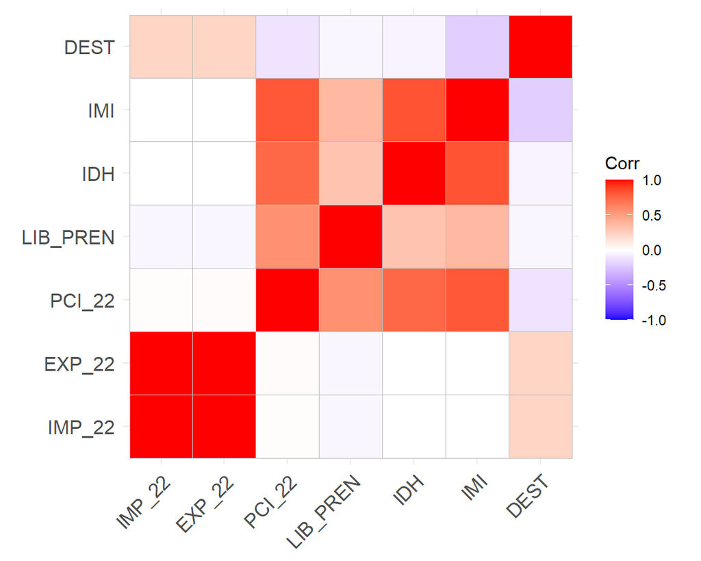

> Esta matriz de correlación muestra relaciones lineanes entre las variables. El color rojo indica una correlación positiva cercanas a 1, el blanco correlaciones débiles o nulas, y las azules correlaciones negativas cercanas a -1

### KMO

```
Kaiser-Meyer-Olkin factor adequacy
Call: psych::KMO(r = corMatrix)
Overall MSA =  0.64
MSA for each item =
  IMP_22   EXP_22   PCI_22 LIB_PREN      IDH      IMI     DEST
    0.51     0.51     0.74     0.66     0.73     0.70     0.58
```

> Matriz identidad

```
[1] FALSE
```

> Matriz singular

```
[1] FALSE
```

### RESULTADOS

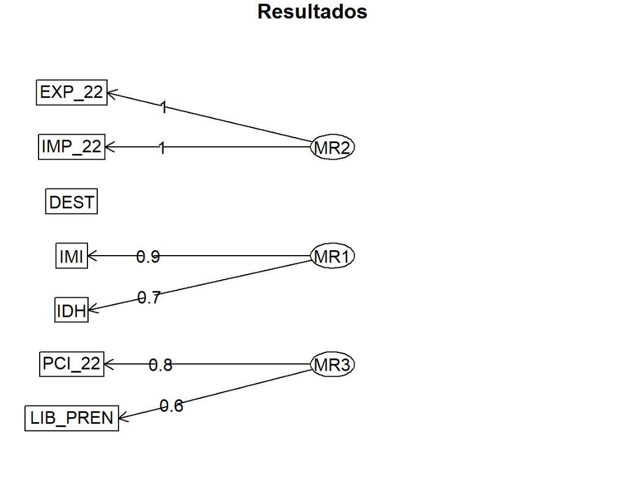

> Los resultados han arrojado tres grupos: Grupo 1: “Estabilidad Económica Internacional” Grupo 2: “Desarrollo e innovación social” Grupo 3: “Instituciones y Transparencia”

## Column {data-width=500}

### APORTACIÓN A LOS FACTORES

```
      DEST   LIB_PREN        IDH     IMP_22     EXP_22     PCI_22        IMI
0.07753653 0.35774174 0.67944153 0.99739932 0.99755570 1.00209822 1.00388730
```

### VARIABLES QUE CONTRIBUYEN A MÁS DE UN FACTOR

```
  IMP_22   EXP_22 LIB_PREN      IMI      IDH     DEST   PCI_22
1.006449 1.006451 1.188135 1.242091 1.469563 1.748048 1.819585
```

### TUCKER LEWIS

```
[1] -0.7734405
```

### RMS

```
[1] 0.02086332
```

### RMSEA

```
     RMSEA      lower      upper confidence
 0.9808065  0.9036000  1.0678866  0.9000000
```

### BIC

```
[1] 377.909
```

# HIPOTESIS

## Column {data-width=500}

### HIPOTESIS 1

> La paz y estabilidad en un país se ve asociada postivamente con un mayor desarrollo humano y tecnologico, una menor percepción de corrupción y una mayor libertad de prensa

Regresion: modelo 1

|  | &nbsp;apropiacion (I) |
| --- | --- |
| (Intercept) | -2.757*** |
|  | (0.420) |
| IDH | 1.594* |
|  | (0.726) |
| IMI | -0.008 |
|  | (0.008) |
| PCI_22 | 0.026*** |
|  | (0.007) |
| LIB_PREN | 0.011** |
|  | (0.004) |
| Num.Obs. | 135 |
| R2 | 0.497 |
| R2 Adj. | 0.482 |
| AIC | 301.2 |
| BIC | 318.7 |
| Log.Lik. | -144.622 |
| F | 32.160 |
| RMSE | 0.71 |

+ p < 0.1, * p < 0.05, ** p < 0.01, *** p < 0.001

### HIPOTESIS 2

> La paz no sólo es un factor social e institucional, sino que para que un país sea realmente pacífico tiene existir un desarrollo economico prospero

Regresion: modelo 2

|  | &nbsp;apropiacion (II) |
| --- | --- |
| (Intercept) | -2.766*** |
|  | (0.423) |
| IDH | 1.573* |
|  | (0.737) |
| IMI | -0.007 |
|  | (0.008) |
| PCI_22 | 0.026*** |
|  | (0.007) |
| LIB_PREN | 0.011** |
|  | (0.004) |
| IMP_22 | 0.000 |
|  | (0.001) |
| EXP_22 | 0.001 |
|  | (0.003) |
| Num.Obs. | 135 |
| R2 | 0.499 |
| R2 Adj. | 0.475 |
| AIC | 304.9 |
| BIC | 328.1 |
| Log.Lik. | -144.440 |
| F | 21.225 |
| RMSE | 0.71 |

+ p < 0.1, * p < 0.05, ** p < 0.01, *** p < 0.001

### HIPOTESIS 3

> Para la paz existen también otros factores, tanto sociales como económicos, que explican la paz de un país, como podría ser el desempleo, puesto que un país con una mayor fuerza laboral tiene un mejor desarrollo económico y social, así como un crecimiento del PBI mayor.

Regresion: modelo 3

|  | &nbsp;apropiacion (III) |
| --- | --- |
| (Intercept) | -2.252*** |
|  | (0.394) |
| IDH | 1.570* |
|  | (0.765) |
| IMI | -0.013 |
|  | (0.008) |
| PCI_22 | 0.036*** |
|  | (0.006) |
| IMP_22 | 0.000 |
|  | (0.001) |
| EXP_22 | 0.001 |
|  | (0.003) |
| PBI_2022 | -0.009 |
|  | (0.010) |
| DEST | -0.018 |
|  | (0.014) |
| Num.Obs. | 135 |
| R2 | 0.481 |
| R2 Adj. | 0.452 |
| AIC | 311.6 |
| BIC | 337.8 |
| Log.Lik. | -146.815 |
| F | 16.799 |
| RMSE | 0.72 |

+ p < 0.1, * p < 0.05, ** p < 0.01, *** p < 0.001

### COMPARACIÓN DE MODELOS

Resultados de todos los modelos

|  | &nbsp;apropiacion (I) | &nbsp;apropiacion (II) | &nbsp;apropiacion (III) |
| --- | --- | --- | --- |
| (Intercept) | -2.757*** | -2.766*** | -2.252*** |
|  | (0.420) | (0.423) | (0.394) |
| IDH | 1.594* | 1.573* | 1.570* |
|  | (0.726) | (0.737) | (0.765) |
| IMI | -0.008 | -0.007 | -0.013 |
|  | (0.008) | (0.008) | (0.008) |
| PCI_22 | 0.026*** | 0.026*** | 0.036*** |
|  | (0.007) | (0.007) | (0.006) |
| LIB_PREN | 0.011** | 0.011** |  |
|  | (0.004) | (0.004) |  |
| IMP_22 |  | 0.000 | 0.000 |
|  |  | (0.001) | (0.001) |
| EXP_22 |  | 0.001 | 0.001 |
|  |  | (0.003) | (0.003) |
| PBI_2022 |  |  | -0.009 |
|  |  |  | (0.010) |
| DEST |  |  | -0.018 |
|  |  |  | (0.014) |
| Num.Obs. | 135 | 135 | 135 |
| R2 | 0.497 | 0.499 | 0.481 |
| R2 Adj. | 0.482 | 0.475 | 0.452 |
| AIC | 301.2 | 304.9 | 311.6 |
| BIC | 318.7 | 328.1 | 337.8 |
| Log.Lik. | -144.622 | -144.440 | -146.815 |
| F | 32.160 | 21.225 | 16.799 |
| RMSE | 0.71 | 0.71 | 0.72 |

+ p < 0.1, * p < 0.05, ** p < 0.01, *** p < 0.001

## Column {data-width=500}

### MODELOS ESTANDARIZADO 1

Regresion: modelo 1 con coeficientes estandarizados usando lm.beta()

|  | &nbsp;apropiacion (I) |
| --- | --- |
| IDH | 0.252 |
|  | (0.726) |
| IMI | -0.126 |
|  | (0.008) |
| PCI_22 | 0.471 |
|  | (0.007) |
| LIB_PREN | 0.207 |
|  | (0.004) |
| Num.Obs. | 135 |
| R2 | 0.497 |
| R2 Adj. | 0.482 |
| AIC | 301.2 |
| BIC | 318.7 |
| Log.Lik. | -144.624 |
| RMSE | 0.71 |

+ p < 0.1, * p < 0.05, ** p < 0.01, *** p < 0.001

### MODELOS ESTANDARIZADO 2

Regresion: modelo 2 con coeficientes estandarizados usando lm.beta()

|  | &nbsp;apropiacion (II) |
| --- | --- |
| IDH | 0.249 |
|  | (0.737) |
| IMI | -0.121 |
|  | (0.008) |
| PCI_22 | 0.464 |
|  | (0.007) |
| LIB_PREN | 0.209 |
|  | (0.004) |
| IMP_22 | -1.845 |
|  | (0.001) |
| EXP_22 | 1.877 |
|  | (0.003) |
| Num.Obs. | 135 |
| R2 | 0.499 |
| R2 Adj. | 0.475 |
| AIC | 304.9 |
| BIC | 328.1 |
| Log.Lik. | -144.442 |
| RMSE | 0.71 |

+ p < 0.1, * p < 0.05, ** p < 0.01, *** p < 0.001

### MODELO ESTANDARIZADO 3

Regresion: modelo 3 con coeficientes estandarizados usando lm.beta()

|  | &nbsp;apropiacion (III) |
| --- | --- |
| IDH | 0.248 |
|  | (0.765) |
| IMI | -0.211 |
|  | (0.008) |
| PCI_22 | 0.646 |
|  | (0.006) |
| IMP_22 | -2.173 |
|  | (0.001) |
| EXP_22 | 2.212 |
|  | (0.003) |
| PBI_2022 | -0.059 |
|  | (0.010) |
| DEST | -0.089 |
|  | (0.014) |
| Num.Obs. | 135 |
| R2 | 0.481 |
| R2 Adj. | 0.452 |
| AIC | 311.6 |
| BIC | 337.8 |
| Log.Lik. | -146.817 |
| RMSE | 0.72 |

+ p < 0.1, * p < 0.05, ** p < 0.01, *** p < 0.001

Resultados de todos los modelos

|  | &nbsp;apropiacion (I) | &nbsp;apropiacion (II) | &nbsp;apropiacion (III) |
| --- | --- | --- | --- |
| (Intercept) | -2.757*** | -2.766*** | -2.252*** |
|  | [-3.588, -1.927] | [-3.603, -1.929] | [-3.032, -1.472] |
| IDH | 1.594* | 1.573* | 1.570* |
|  | [0.157, 3.031] | [0.116, 3.031] | [0.056, 3.084] |
| IMI | -0.008 | -0.007 | -0.013 |
|  | [-0.023, 0.008] | [-0.023, 0.008] | [-0.030, 0.004] |
| PCI_22 | 0.026*** | 0.026*** | 0.036*** |
|  | [0.012, 0.040] | [0.012, 0.040] | [0.023, 0.048] |
| LIB_PREN | 0.011** | 0.011** |  |
|  | [0.003, 0.019] | [0.003, 0.019] |  |
| IMP_22 |  | 0.000 | 0.000 |
|  |  | [-0.003, 0.002] | [-0.003, 0.002] |
| EXP_22 |  | 0.001 | 0.001 |
|  |  | [-0.005, 0.006] | [-0.005, 0.007] |
| PBI_2022 |  |  | -0.009 |
|  |  |  | [-0.030, 0.011] |
| DEST |  |  | -0.018 |
|  |  |  | [-0.046, 0.010] |
| Num.Obs. | 135 | 135 | 135 |
| R2 | 0.497 | 0.499 | 0.481 |
| R2 Adj. | 0.482 | 0.475 | 0.452 |
| AIC | 301.2 | 304.9 | 311.6 |
| BIC | 318.7 | 328.1 | 337.8 |
| Log.Lik. | -144.622 | -144.440 | -146.815 |
| F | 32.160 | 21.225 | 16.799 |
| RMSE | 0.71 | 0.71 | 0.72 |

+ p < 0.1, * p < 0.05, ** p < 0.01, *** p < 0.001

# MODELOS

## Column {data-width=500}

### COMPARACION

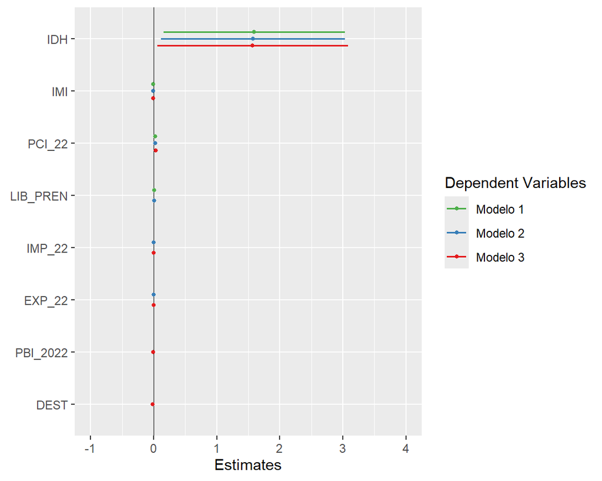

### TABLA ANOVA

Tabla ANOVA para comparar modelos

| Res.Df | RSS | Df | Sum of Sq | F | Pr(>F) |
| --- | --- | --- | --- | --- | --- |
| 130 | 67.35271 | NA | NA | NA | NA |
| 128 | 67.17124 | 2 | 0.1814638 | 0.1656138 | 0.8475562 |
| 127 | 69.57726 | 1 | -2.4060116 | NA | NA |

## Column {data-width=500}

### LINEALIDAD

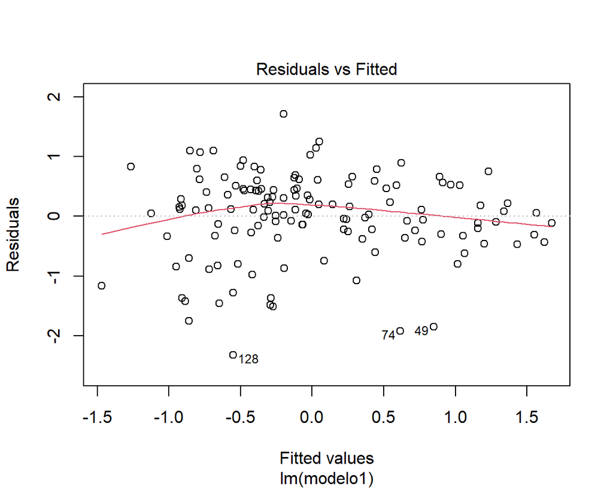

### HOMOCEDEASTICIDAD

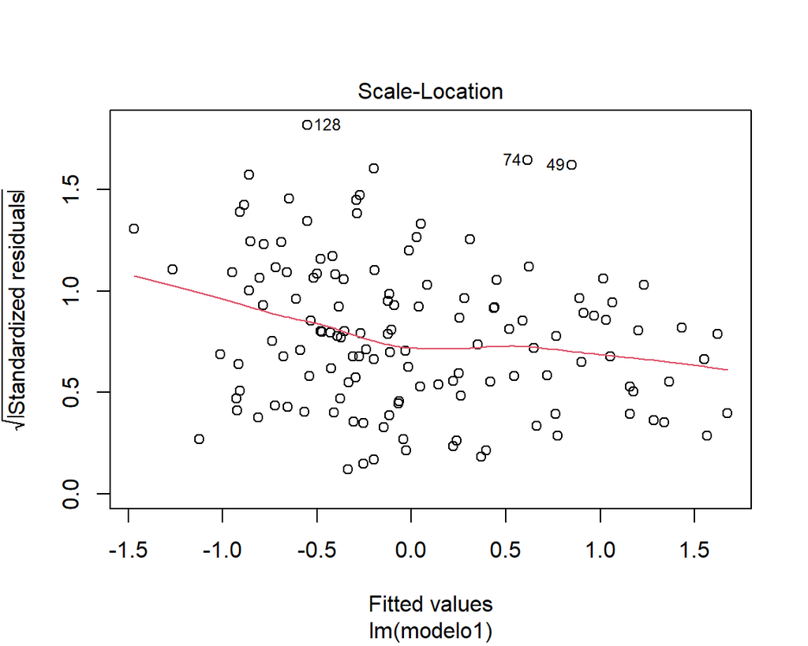

studentized Breusch-Pagan test

|  | BP | df | p.value |
| --- | --- | --- | --- |
| BP | 13.42967 | 4 | 0.0093564 |

### NORMALIDAD DE RESIDUOS

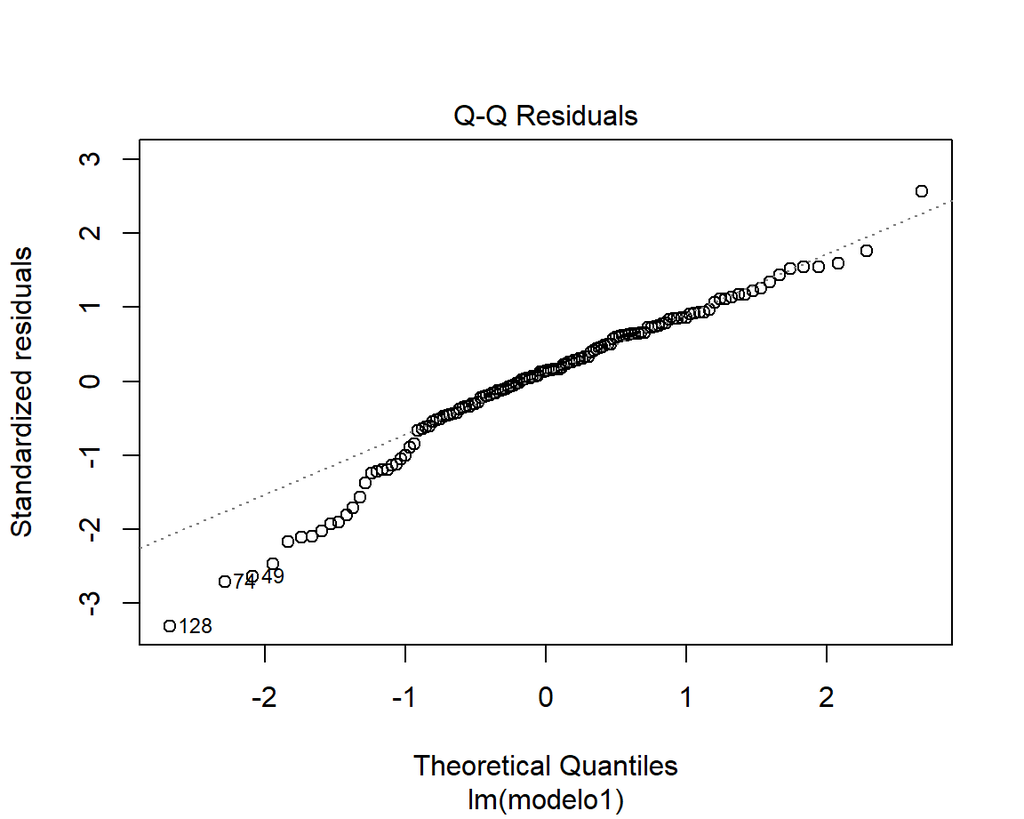

Shapiro-Wilk normality test

|  | SW | p.value |
| --- | --- | --- |
| W | 0.9571355 | 0.0003132 |